# Homework 1: Visualizing & Modeling Variability

**Load some handy packages:**

```r
suppressPackageStartupMessages(library(dplyr))
suppressPackageStartupMessages(library(ggplot2))
```

# Births

```r
#load the fivethirtyeight library
suppressPackageStartupMessages(library(fivethirtyeight))

#load the births data
data(US_births_2000_2014)
head(US_births_2000_2014)
```

```
## # A tibble: 6 x 6
##    year month date_of_month       date day_of_week births
##   <int> <int>         <int>     <date>       <ord>  <int>
## 1  2000     1             1 2000-01-01         Sat   9083
## 2  2000     1             2 2000-01-02         Sun   8006
## 3  2000     1             3 2000-01-03         Mon  11363
## 4  2000     1             4 2000-01-04        Tues  13032
## 5  2000     1             5 2000-01-05         Wed  12558
## 6  2000     1             6 2000-01-06       Thurs  12466
```

```r
nrow(US_births_2000_2014)
```

```
## [1] 5479
```

## Exercise 1

1a. Unit of observation is total number of births in US on a given date and day 1b. 5479 units of observations in this data

## Exercise 2

2a.

```r
library(dplyr)
Births2014 <- US_births_2000_2014 %>% filter(year == 2014)
head(Births2014,2)
```

```
## # A tibble: 2 x 6
##    year month date_of_month       date day_of_week births
##   <int> <int>         <int>     <date>       <ord>  <int>
## 1  2014     1             1 2014-01-01         Wed   8018
## 2  2014     1             2 2014-01-02       Thurs  11171
```

2b. Construct a univariate plot that allows you to visualize the variability in births from day to day in 2014.

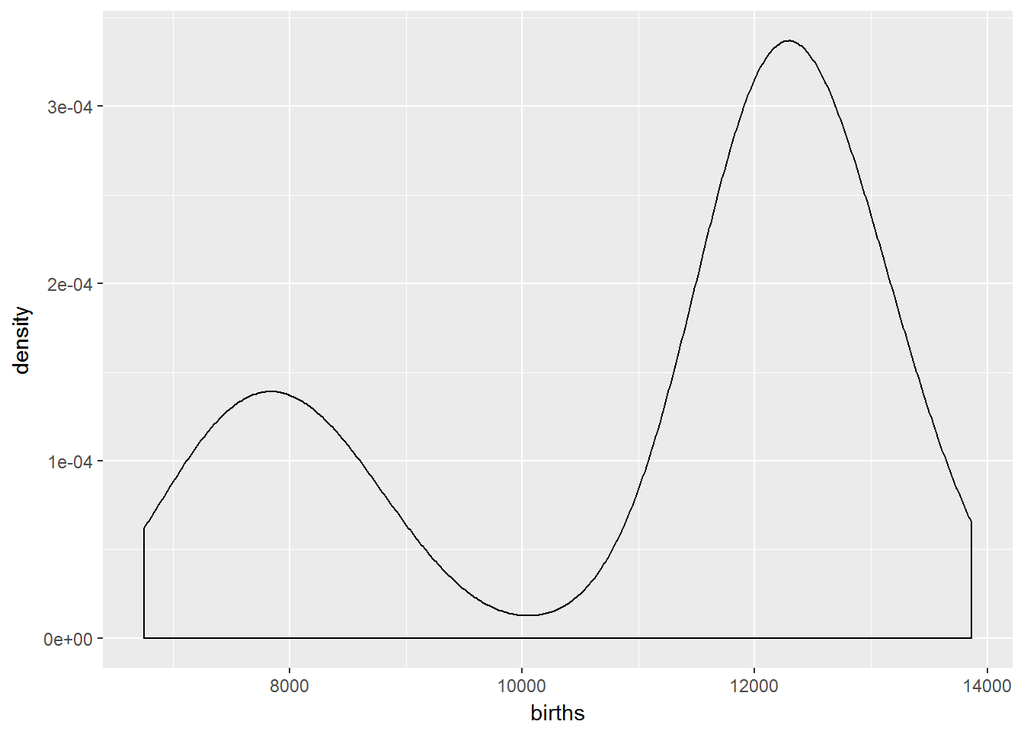

```r
Births2014 %>% ggplot(aes(births)) + geom_density()
```

2c. The time of year might explain some of this variability. Construct a plot that illustrates the relationship between births and date in 2014. NOTE: Make sure that births, our variable of interest, is on the y-axis.

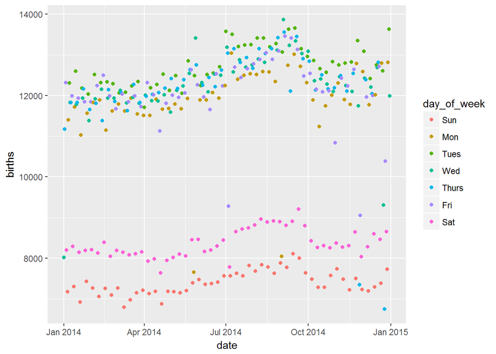

```r
Births2014 %>% ggplot(aes(y= births, x =date, colour = day_of_week)) + geom_point()
```

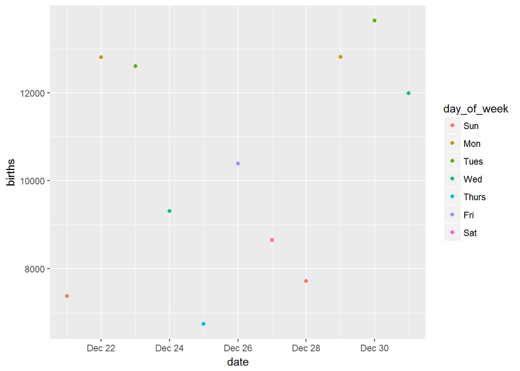

```r
Births2014[355:365,] %>% ggplot(aes(y= births, x =date, colour = day_of_week)) + geom_point()
```

Number of Births in 2014 in US fall are segregated into two sets: Weekdays and Weekend/Holidays. We see in the table below that mean births during weekdays are higher than weekends.

```r
Births2014 %>% group_by(day_of_week) %>%summarize(means = mean(births))
```

```
## # A tibble: 7 x 2
##   day_of_week     means
##         <ord>     <dbl>
## 1         Sun  7396.827
## 2         Mon 11872.596
## 3        Tues 12724.558
## 4         Wed 12238.283
## 5       Thurs 12181.462
## 6         Fri 12113.442
## 7         Sat  8363.096
```

## Exercise 3

```r
allyears <- full_join(US_births_1994_2003, US_births_2000_2014)
```

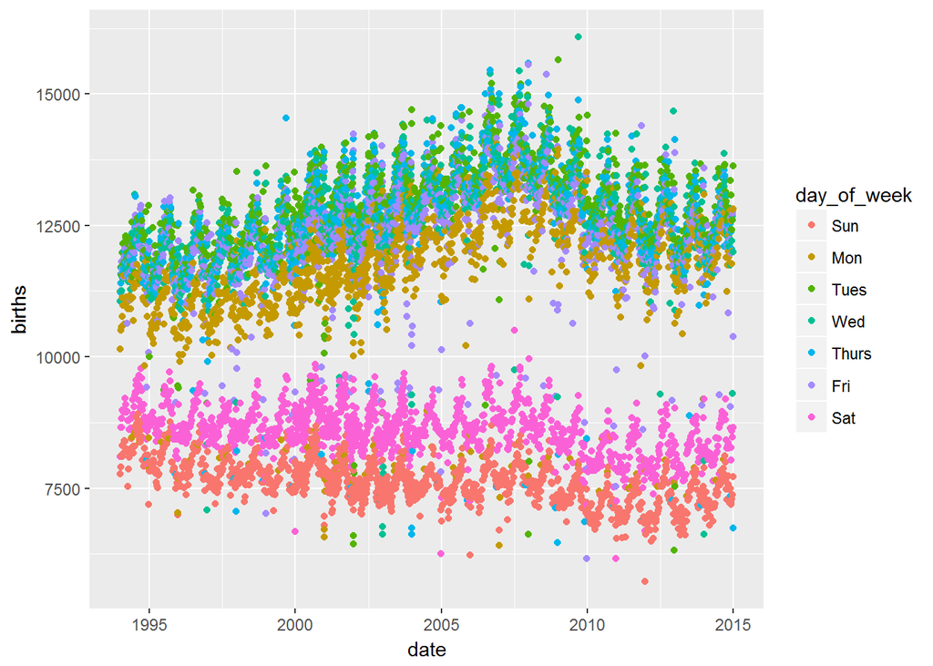

```r
allyears %>% ggplot(aes(y = births, x = date,color = day_of_week)) + geom_point()
```

3b. We see that the pattern segregation of number of births on weekdays/weekends exists accross all years. However, we separation between these two groups has increased over years.

## Exercise 4

4a.

```r
frionly <- allyears %>% filter(day_of_week == 'Fri') %>% mutate(fri13 = (date_of_month == 13))

head(frionly)
```

```
## # A tibble: 6 x 7
##    year month date_of_month       date day_of_week births fri13
##   <int> <int>         <int>     <date>       <ord>  <int> <lgl>
## 1  1994     1             7 1994-01-07         Fri  11251 FALSE
## 2  1994     1            14 1994-01-14         Fri  11570 FALSE
## 3  1994     1            21 1994-01-21         Fri  11811 FALSE
## 4  1994     1            28 1994-01-28         Fri  11666 FALSE
## 5  1994     2             4 1994-02-04         Fri  11677 FALSE
## 6  1994     2            11 1994-02-11         Fri  11517 FALSE
```

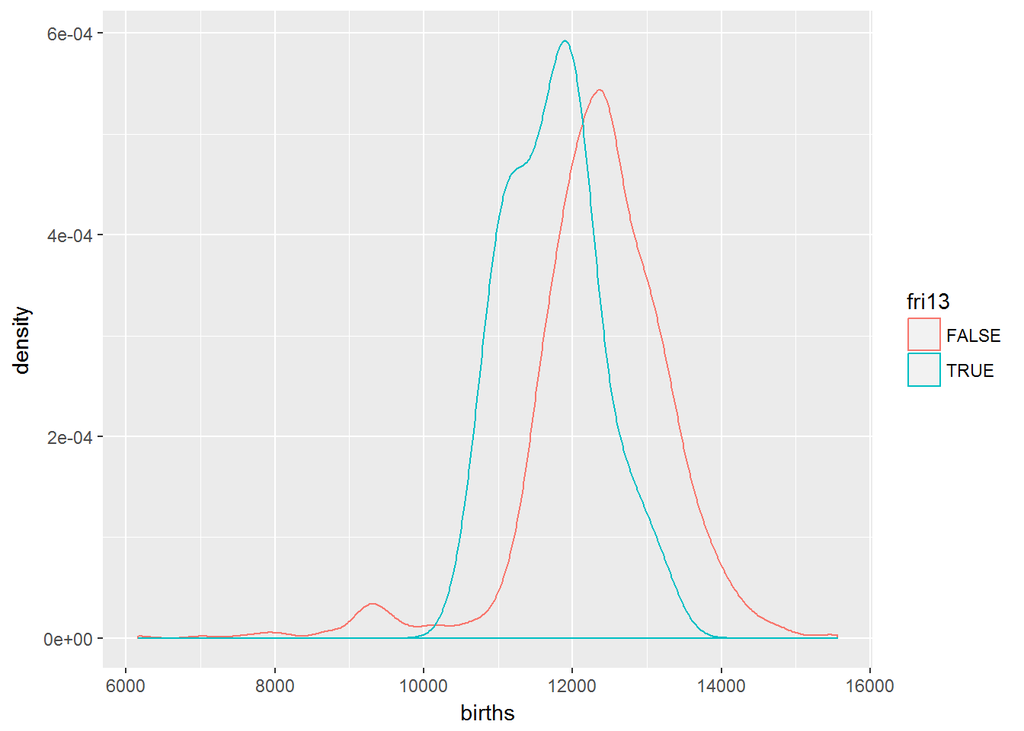

```r
frionly %>% ggplot(aes(births, color= fri13)) +geom_density() #facet_wrap(~fri13)
```

Yes, we see that the density plot from FRI13 has lower mean than births on other fri dates.

# Interaction

```r
campaigns = read.csv("https://www.macalester.edu/~ajohns24/data/CampaignSpending.csv")
```

## Exercise 5

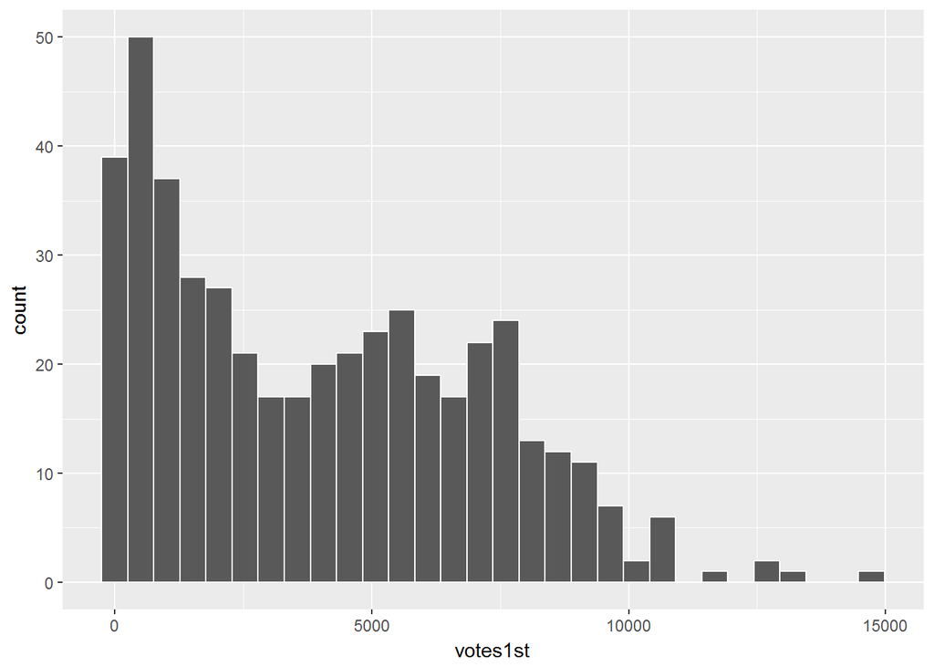

```r
campaigns = read.csv("https://www.macalester.edu/~ajohns24/data/CampaignSpending.csv")

#names(campaigns)
ggplot(campaigns, aes(x=votes1st)) +
    geom_histogram(color="white")
```

5a

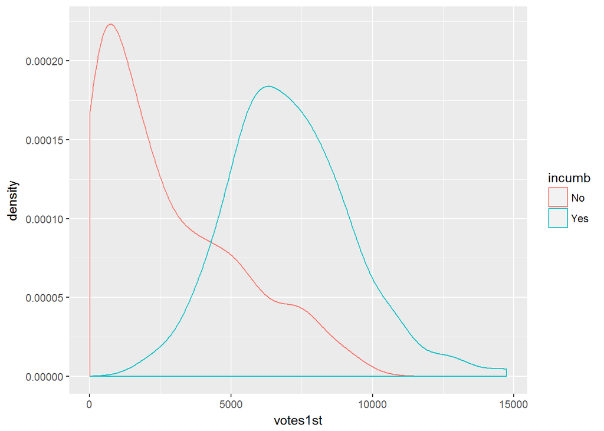

```r
ggplot(campaigns, aes(x=votes1st, color = incumb)) +
    geom_density()
```

5b

```r
campaigns %>% group_by(incumb) %>%
    summarize(means=mean(votes1st, na.rm=TRUE))
```

```
## # A tibble: 2 x 2
##   incumb    means
##   <fctr>    <dbl>
## 1     No 2722.012
## 2    Yes 7083.241
```

5c

```r
model1 <- lm(votes1st ~ incumb, data=campaigns)
summary(model1)
```

```
##
## Call:
## lm(formula = votes1st ~ incumb, data = campaigns)
##
## Residuals:
##    Min     1Q Median     3Q    Max
##  -5075  -1821   -599   1440   7659
##
## Coefficients:
##             Estimate Std. Error t value Pr(>|t|)
## (Intercept)   2722.0      131.6   20.69   <2e-16 ***
## incumbYes     4361.2      241.9   18.03   <2e-16 ***
## ---
## Signif. codes:  0 '***' 0.001 '**' 0.01 '*' 0.05 '.' 0.1 ' ' 1
##
## Residual standard error: 2376 on 461 degrees of freedom
##   (1 observation deleted due to missingness)
## Multiple R-squared:  0.4136, Adjusted R-squared:  0.4123
## F-statistic: 325.1 on 1 and 461 DF,  p-value: < 2.2e-16
```

Mean estimate of number of 1st preference votes for a challenger is 2722.0 and incumbent has 4361.2 more votes than challenger as 1st preference.

## Exercise 6

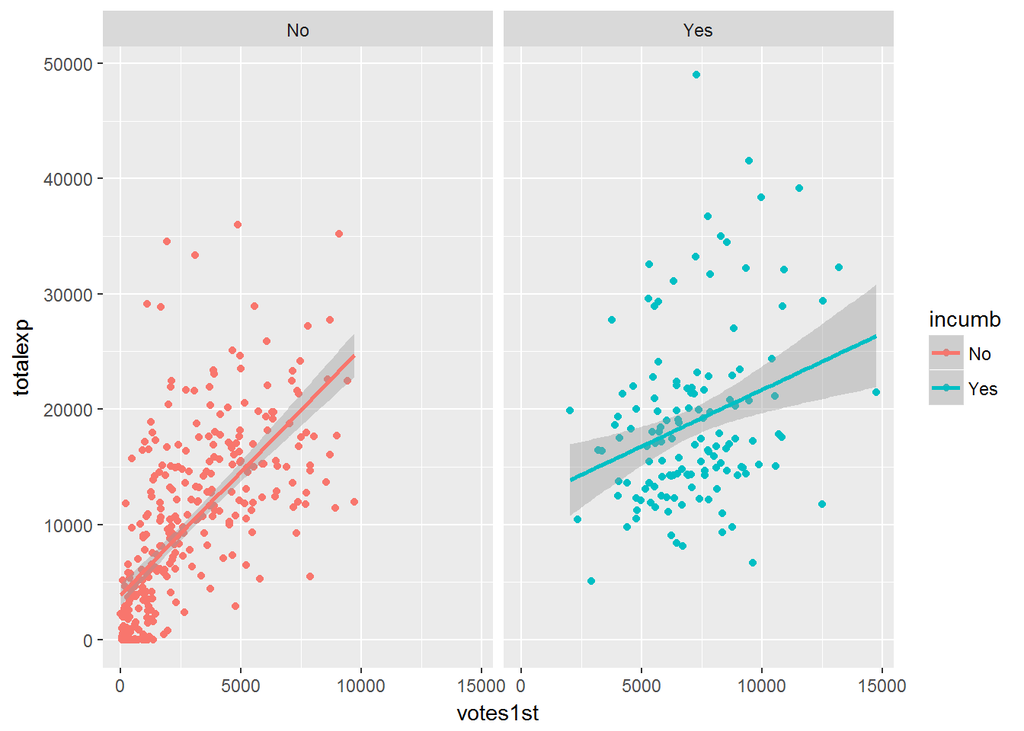

```r
campaigns %>% ggplot(aes(x = votes1st, y= totalexp, color = incumb)) + geom_point() + geom_smooth(method = 'lm') + facet_wrap(~incumb)
```

```r
model2 <- lm(votes1st ~ totalexp + incumb, data=campaigns)
summary(model2)
```

```
##
## Call:
## lm(formula = votes1st ~ totalexp + incumb, data = campaigns)
##
## Residuals:
##    Min     1Q Median     3Q    Max
##  -5259  -1132   -433   1042   7207
##
## Coefficients:
##              Estimate Std. Error t value Pr(>|t|)
## (Intercept) 1.031e+03  1.575e+02   6.549 1.55e-10 ***
## totalexp    1.745e-01  1.179e-02  14.803  < 2e-16 ***
## incumbYes   2.764e+03  2.266e+02  12.197  < 2e-16 ***
## ---
## Signif. codes:  0 '***' 0.001 '**' 0.01 '*' 0.05 '.' 0.1 ' ' 1
##
## Residual standard error: 1957 on 460 degrees of freedom
##   (1 observation deleted due to missingness)
## Multiple R-squared:  0.6028, Adjusted R-squared:  0.6011
## F-statistic:   349 on 2 and 460 DF,  p-value: < 2.2e-16
```

6b. Full model $votes1st = 1.031e+03 + (1.745e-01)*totalexp + (2.764e+03)* incumbYes $

Challengers: $votes1st = 1.031e+03 + 1.745e-01 totalexp $

Incumbents: $votes1st = 3.795e+03 + (1.745e-01)*totalexp$

6c. Full model: 1. intercept: The number of 1st preference votes for a challengers when the expense is zero 2. Total exp- co-efficient: The amount of increase in 1st preference votes when totalexp increases by a Euro 3. IncumbYes Coeff: The number of 1st preference votes that a incumb will recieve more than a challenger when total expense is zero

Challenger model: 1. intercept: The number of 1st preference votes for a challengers when the expense is zero 2. Total exp- co-efficient: The amount of increase in 1st preference votes when totalexp increases by a Euro

Incumbent Model: Challenger model: 1. intercept: The number of 1st preference votes for a incumbent when the expense is zero 2. Total exp- co-efficient: The amount of increase in 1st preference votes when totalexp increases by a Euro

```r
test1 = data.frame(totalexp = 10000, incumb = 'No')

predict(model2, test1)
```

```
##        1
## 2776.177
```

```r
test2 = data.frame(totalexp = 10000, incumb = 'Yes')
predict(model2,test2)
```

```
##        1
## 5540.192
```

```r
suppressPackageStartupMessages(library(mosaic))
model2_pred <- makeFun(model2)
model2_pred(incumb="No", totalexp=10000)
```

```
##        1
## 2776.177
```

```r
model2_pred(incumb="Yes", totalexp=10000)
```

```
##        1
## 5540.192
```

## Exercise 7

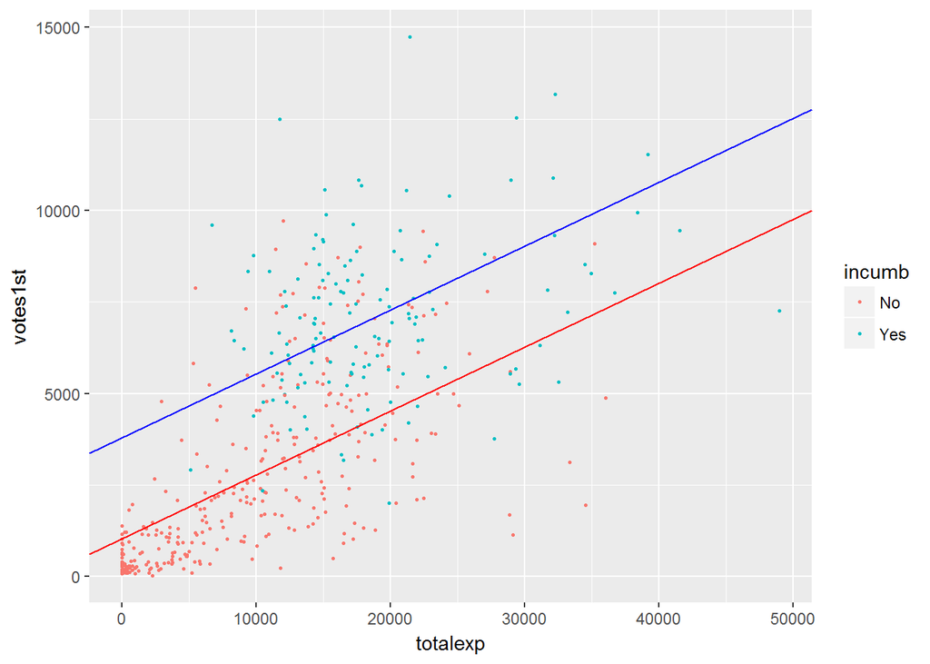

```r
ggplot(campaigns, aes(x=totalexp, y=votes1st, col=incumb)) +
    geom_point(size=0.5) +
    geom_abline(intercept=1031, slope=0.1745, col="red") +
    geom_abline(intercept=3795, slope=0.1745, col="blue")
```

```r
newmodel <- lm(votes1st ~ totalexp * incumb, campaigns)
summary(newmodel)
```

```
##
## Call:
## lm(formula = votes1st ~ totalexp * incumb, data = campaigns)
##
## Residuals:
##     Min      1Q  Median      3Q     Max
## -5989.7 -1059.0  -328.8   917.9  7442.0
##
## Coefficients:
##                      Estimate Std. Error t value Pr(>|t|)
## (Intercept)         690.51688  168.60193   4.096 4.98e-05 ***
## totalexp              0.20966    0.01355  15.473  < 2e-16 ***
## incumbYes          4813.89319  472.40711  10.190  < 2e-16 ***
## totalexp:incumbYes   -0.12587    0.02563  -4.910 1.27e-06 ***
## ---
## Signif. codes:  0 '***' 0.001 '**' 0.01 '*' 0.05 '.' 0.1 ' ' 1
##
## Residual standard error: 1910 on 459 degrees of freedom
##   (1 observation deleted due to missingness)
## Multiple R-squared:  0.6226, Adjusted R-squared:  0.6201
## F-statistic: 252.4 on 3 and 459 DF,  p-value: < 2.2e-16
```

Full Model:

votes1st = 690.51 + 0.20966totalexp + 4813.89incumbYes - 0.12587Totalexp*incumbYes Full model: 1. intercept: The number of 1st preference votes for a challenger when the expense is zero 2. Total exp- co-efficient: The amount of increase in 1st preference votes when totalexp increases by a Euro for a challenger 3. IncumbYes Coeff: The number of 1st preference votes that a incumb will recieve more than a challenger when total expense is zero 4. Total*IncumbYes Coeff: The amount of increase that a incumb will recieve more than a challenger when total expense increase by 1

Challenger votes1st= 690.51 + 0.20966totalexp

Incumbent votes1st= 690.51 + 4813.9 + (0.20966 -0.12587)*totalexp

```r
test3 = data.frame(totalexp = 10000, incumb ='No')
predict(newmodel, test3)
```

```
##        1
## 2787.095
```

```r
test4 = data.frame(totalexp = 10000, incumb ='Yes')
predict(newmodel, test4)
```

```
##        1
## 6342.282
```

```r
newmodel_pred <- makeFun(newmodel)
newmodel_pred(incumb="No", totalexp=10000)
```

```
##        1
## 2787.095
```

```r
newmodel_pred(incumb="Yes", totalexp=10000)
```

```
##        1
## 6342.282
```

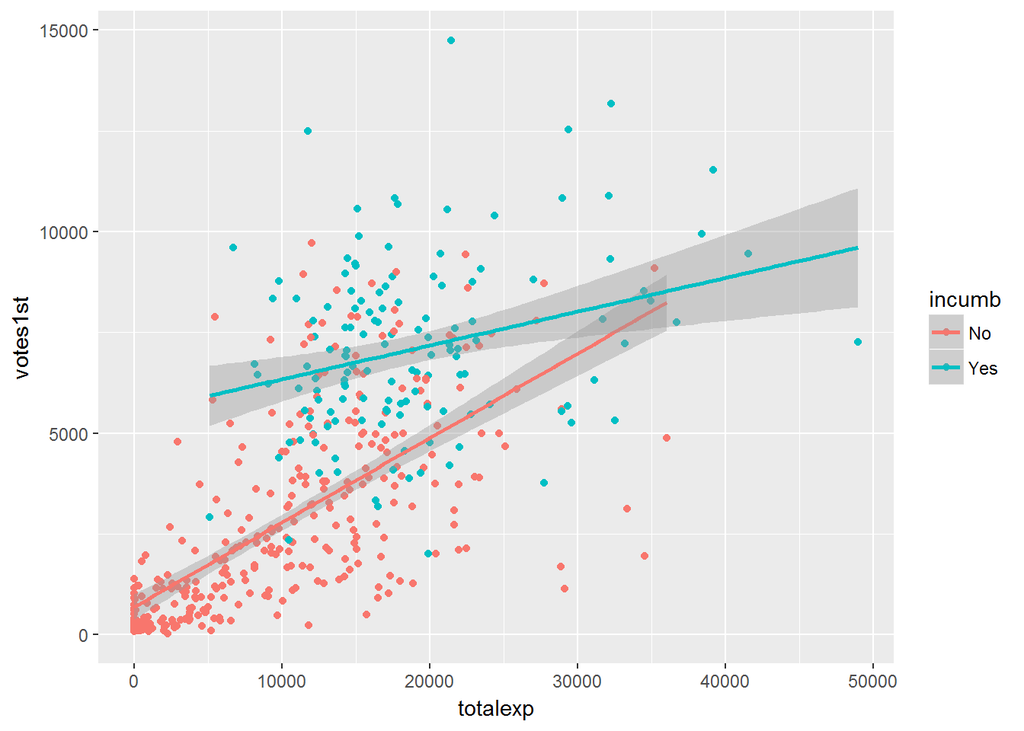

```r
ggplot(campaigns, aes(x=totalexp, y=votes1st, col=incumb)) +
    geom_point() +
    geom_smooth(method="lm")
```

# Covariates

```r
#Load the data:suppressPackageStartupMessages(library(mosaic))
data(CPS85)
head(CPS85,3)
```

```
##   wage educ race sex hispanic south married exper union age sector
## 1  9.0   10    W   M       NH    NS Married    27   Not  43  const
## 2  5.5   12    W   M       NH    NS Married    20   Not  38  sales
## 3  3.8   12    W   F       NH    NS  Single     4   Not  22  sales
```

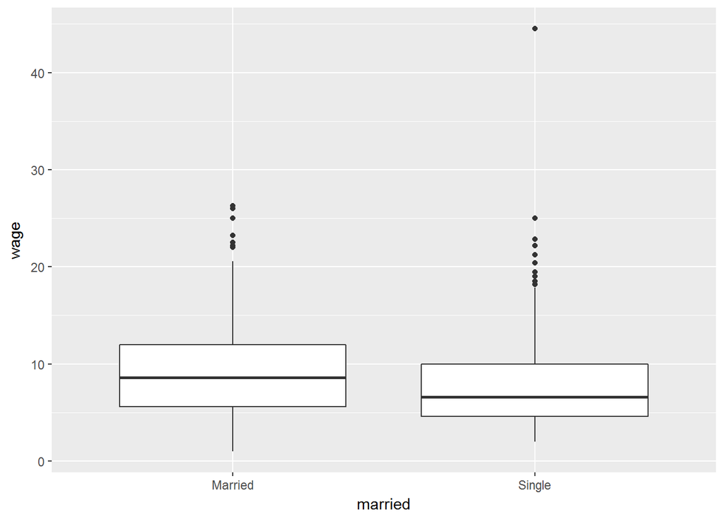

```r
ggplot(CPS85, aes(y=wage, x=married)) +
    geom_boxplot()
```

```r
cpsmod1 <- lm(wage ~ married, data = CPS85)
msummary(cpsmod1)
```

```
##               Estimate Std. Error t value Pr(>|t|)
## (Intercept)     9.3985     0.2736  34.356   <2e-16 ***
## marriedSingle  -1.0866     0.4660  -2.332   0.0201 *
##
## Residual standard error: 5.118 on 532 degrees of freedom
## Multiple R-squared:  0.01012,    Adjusted R-squared:  0.008255
## F-statistic: 5.437 on 1 and 532 DF,  p-value: 0.02009
```

## Exercise 8

```r
names(CPS85)
```

```
##  [1] "wage"     "educ"     "race"     "sex"      "hispanic" "south"
##  [7] "married"  "exper"    "union"    "age"      "sector"
```

```r
CPS85 %>% group_by(married,sex) %>% summarize(meanwage= mean(educ))
```

```
## # A tibble: 4 x 3
## # Groups:   married [?]
##   married    sex meanwage
##    <fctr> <fctr>    <dbl>
## 1 Married      F 12.86420
## 2 Married      M 13.02660
## 3  Single      F 13.33735
## 4  Single      M 12.99010
```

Age could be a confounding variable

## Exercise 9

```r
cpsmod2 <- lm(wage ~ exper + married, data = CPS85)
summary(cpsmod2)
```

```
##
## Call:
## lm(formula = wage ~ exper + married, data = CPS85)
##
## Residuals:
##    Min     1Q Median     3Q    Max
## -8.499 -3.675 -1.224  2.097 36.515
##
## Coefficients:
##               Estimate Std. Error t value Pr(>|t|)
## (Intercept)    8.85583    0.46510  19.041   <2e-16 ***
## exper          0.02680    0.01858   1.442    0.150
## marriedSingle -0.89772    0.48364  -1.856    0.064 .
## ---
## Signif. codes:  0 '***' 0.001 '**' 0.01 '*' 0.05 '.' 0.1 ' ' 1
##
## Residual standard error: 5.113 on 531 degrees of freedom
## Multiple R-squared:  0.01398,    Adjusted R-squared:  0.01026
## F-statistic: 3.763 on 2 and 531 DF,  p-value: 0.02382
```

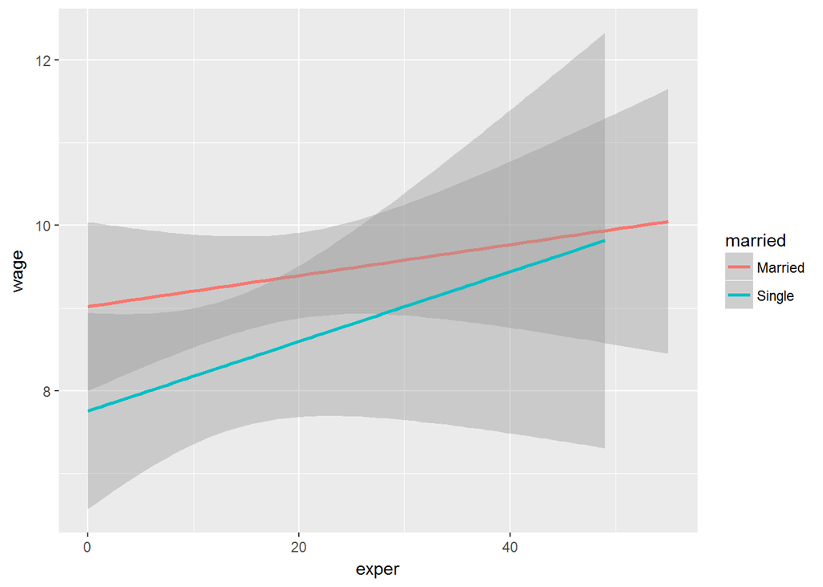

```r
ggplot(CPS85, aes(y=wage, x=exper, color=married)) +
    geom_smooth(method="lm")
```

9c. Compare two workers that both have 10 years of experience but one is married and the other is single. By how much do their predicted wages to differ? Use the model formula to calculate this difference and the plot to provide intuition.

```r
test4 = data.frame(exper = 10, married = 'Married')
test5 = data.frame(exper = 10, married = 'Single')
test6 = data.frame(exper = 20, married = 'Married')
test7 = data.frame(exper = 20, married = 'Single')
predict(cpsmod2,test4) - predict(cpsmod2,test5)
```

```
##         1
## 0.8977163
```

```r
predict(cpsmod2,test6) - predict(cpsmod2,test7)
```

```
##         1
## 0.8977163
```

The difference is same because the model assumes the slopes to be same for married and single people. This is not th case in reality as can be seen from the graph. So, we should add the interaction term and we might get answers as expected from the graph.

The difference in wages should decrease with time.

```r
cpsmod21 <- lm(wage ~ exper * married, data = CPS85)
summary(cpsmod21)
```

```
##
## Call:
## lm(formula = wage ~ exper * married, data = CPS85)
##
## Residuals:
##    Min     1Q Median     3Q    Max
## -8.469 -3.753 -1.237  2.150 36.702
##
## Coefficients:
##                     Estimate Std. Error t value Pr(>|t|)
## (Intercept)          9.01957    0.53992  16.705   <2e-16 ***
## exper                0.01871    0.02299   0.814    0.416
## marriedSingle       -1.26343    0.77976  -1.620    0.106
## exper:marriedSingle  0.02339    0.03910   0.598    0.550
## ---
## Signif. codes:  0 '***' 0.001 '**' 0.01 '*' 0.05 '.' 0.1 ' ' 1
##
## Residual standard error: 5.116 on 530 degrees of freedom
## Multiple R-squared:  0.01464,    Adjusted R-squared:  0.009065
## F-statistic: 2.625 on 3 and 530 DF,  p-value: 0.04977
```

```r
predict(cpsmod21,test4) - predict(cpsmod21,test5)
```

```
##       1
## 1.02958
```

```r
predict(cpsmod21,test6) - predict(cpsmod21,test7)
```

```
##         1
## 0.7957244
```

## Exercise 10

```r
cpsmod3 <- lm(wage ~ exper + educ + sector + married, data=CPS85)
summary(cpsmod3)
```

```
##
## Call:
## lm(formula = wage ~ exper + educ + sector + married, data = CPS85)
##
## Residuals:
##     Min      1Q  Median      3Q     Max
## -10.457  -2.840  -0.699   1.871  34.118
##
## Coefficients:
##               Estimate Std. Error t value Pr(>|t|)
## (Intercept)   -3.75175    1.53478  -2.444  0.01484 *
## exper          0.09444    0.01750   5.396 1.03e-07 ***
## educ           0.74744    0.10097   7.403 5.36e-13 ***
## sectorconst    3.00423    1.09770   2.737  0.00641 **
## sectormanag    3.97315    0.76509   5.193 2.97e-07 ***
## sectormanuf    1.67234    0.71877   2.327  0.02036 *
## sectorother    2.13193    0.71085   2.999  0.00284 **
## sectorprof     2.66857    0.67628   3.946 9.03e-05 ***
## sectorsales   -0.17743    0.84820  -0.209  0.83439
## sectorservice -0.12179    0.67254  -0.181  0.85636
## marriedSingle -0.39846    0.42213  -0.944  0.34564
## ---
## Signif. codes:  0 '***' 0.001 '**' 0.01 '*' 0.05 '.' 0.1 ' ' 1
##
## Residual standard error: 4.417 on 523 degrees of freedom
## Multiple R-squared:  0.2752, Adjusted R-squared:  0.2614
## F-statistic: 19.86 on 10 and 523 DF,  p-value: < 2.2e-16
```

10a. 16 parallel planes

10b.The wages differ by 0.3984 dollar per hour

```r
test81 = data.frame(exper = 10, educ = 16, sector = 'service', married = 'Married')
test82 = data.frame(exper = 10, educ = 16, sector = 'service', married = 'Single')

predict(cpsmod3,test81)- predict(cpsmod3,test82)
```

```
##         1
## 0.3984626
```

10c. They differ by 0.3984

```r
test91 = data.frame(exper = 20, educ = 12, sector = 'manuf', married = 'Married')
test92 = data.frame(exper = 20, educ = 12, sector = 'manuf', married = 'Single')

predict(cpsmod3,test91)- predict(cpsmod3,test92)
```

```
##         1
## 0.3984626
```

10d marriedSingle coefficient tells us differene in wage between married and single person when they have same years of experience, education and work in the same industry.

10e. Since in cpsmod3 we have more covariates which explain the variability in wages, there is a lower correlation between wage and married status.

This means although there was correlation between wages and married status, there wasn’t a strong causation.

## Exercise 11

# Least Squares Estimation

```r
#Load the data:
suppressPackageStartupMessages(library(mosaic))
data(Galton)
?Galton
```

```
## starting httpd help server ...
```

```
##  done
```

## Exercise 12

```r
htmodel <- lm(height ~ father, data=Galton)
summary(htmodel)
```

```
##
## Call:
## lm(formula = height ~ father, data = Galton)
##
## Residuals:
##      Min       1Q   Median       3Q      Max
## -10.2683  -2.6689  -0.2092   2.6342  11.9329
##
## Coefficients:
##             Estimate Std. Error t value Pr(>|t|)
## (Intercept) 39.11039    3.22706  12.120   <2e-16 ***
## father       0.39938    0.04658   8.574   <2e-16 ***
## ---
## Signif. codes:  0 '***' 0.001 '**' 0.01 '*' 0.05 '.' 0.1 ' ' 1
##
## Residual standard error: 3.446 on 896 degrees of freedom
## Multiple R-squared:  0.07582,    Adjusted R-squared:  0.07479
## F-statistic: 73.51 on 1 and 896 DF,  p-value: < 2.2e-16
```

1. 2
2. - 4.5

## Exercise 13

```r
htmodelResults <-  data.frame(observed=Galton$height,
    predicted=htmodel$fitted.values, residual=htmodel$residuals)
head(htmodelResults)
```

```
##   observed predicted  residual
## 1     73.2  70.46182  2.738184
## 2     69.2  70.46182 -1.261816
## 3     69.0  70.46182 -1.461816
## 4     69.0  70.46182 -1.461816
## 5     73.5  69.26367  4.236328
## 6     72.5  69.26367  3.236328
```

13b Observed - predicted = residual 13c

```r
mean(htmodelResults$residual)
```

```
## [1] -3.019877e-17
```

13d

```r
summary(htmodel)
```

```
##
## Call:
## lm(formula = height ~ father, data = Galton)
##
## Residuals:
##      Min       1Q   Median       3Q      Max
## -10.2683  -2.6689  -0.2092   2.6342  11.9329
##
## Coefficients:
##             Estimate Std. Error t value Pr(>|t|)
## (Intercept) 39.11039    3.22706  12.120   <2e-16 ***
## father       0.39938    0.04658   8.574   <2e-16 ***
## ---
## Signif. codes:  0 '***' 0.001 '**' 0.01 '*' 0.05 '.' 0.1 ' ' 1
##
## Residual standard error: 3.446 on 896 degrees of freedom
## Multiple R-squared:  0.07582,    Adjusted R-squared:  0.07479
## F-statistic: 73.51 on 1 and 896 DF,  p-value: < 2.2e-16
```

13e. Residual standard error = sd(residuals)

```r
sd(htmodel$residuals)
```

```
## [1] 3.444412
```